# cat

```python
!unzip -q cat.zip -d /content/
```

Check if breed folders are visible

```python
!ls /content/cat
```

```
'American Bobtail'  'Domestic Long Hair'  'Domestic Medium Hair'
```

Split the Dataset into Train / Val / Tes

```python
import os, shutil
from sklearn.model_selection import train_test_split

def split_dataset(source_dir, output_dir, train_ratio=0.7, val_ratio=0.15):
    categories = os.listdir(source_dir)
    for category in categories:
        cat_path = os.path.join(source_dir, category)
        images = [img for img in os.listdir(cat_path) if img.lower().endswith(('.jpg', '.jpeg', '.png'))]
        train, testval = train_test_split(images, test_size=1-train_ratio, random_state=42)
        val, test = train_test_split(testval, test_size=0.5, random_state=42)

        for split_name, split_data in zip(['train', 'val', 'test'], [train, val, test]):
            split_path = os.path.join(output_dir, split_name, category)
            os.makedirs(split_path, exist_ok=True)
            for img in split_data:
                shutil.copy(os.path.join(cat_path, img), os.path.join(split_path, img))

split_dataset('/content/cat', '/content/split_cat')
```

Import Libraries

```python
import os
import tensorflow as tf
from tensorflow.keras.preprocessing.image import ImageDataGenerator
from tensorflow.keras.applications import ResNet50, DenseNet121, MobileNetV3Small
from tensorflow.keras import layers, models
import matplotlib.pyplot as plt
from sklearn.metrics import confusion_matrix, ConfusionMatrixDisplay
import numpy as np
import time
```

Load Split Dataset

```python
img_size = (224, 224)
batch_size = 32

train_path = '/content/split_cat/train'
val_path = '/content/split_cat/val'
test_path = '/content/split_cat/test'

datagen = ImageDataGenerator(rescale=1./255)

train_data = datagen.flow_from_directory(train_path, target_size=img_size, batch_size=batch_size, class_mode='categorical')
val_data = datagen.flow_from_directory(val_path, target_size=img_size, batch_size=batch_size, class_mode='categorical')
test_data = datagen.flow_from_directory(test_path, target_size=img_size, batch_size=batch_size, class_mode='categorical')

class_names = list(train_data.class_indices.keys())
num_classes = len(class_names)
```

```
Found 2156 images belonging to 3 classes.
Found 463 images belonging to 3 classes.
Found 463 images belonging to 3 classes.
```

Build the Model Wrapper Function

```python
def build_model(base_model):
    model = models.Sequential([
        base_model,
        layers.GlobalAveragePooling2D(),
        layers.Dense(256, activation='relu'),
        layers.Dropout(0.5),
        layers.Dense(num_classes, activation='softmax')
    ])
    return model
```

Train All Three Models 'ResNet50' 'DenseNet121' 'MobileNetV3'

```python
pretrained_models = {
    'ResNet50': ResNet50(weights='imagenet', include_top=False, input_shape=(224,224,3)),
    'DenseNet121': DenseNet121(weights='imagenet', include_top=False, input_shape=(224,224,3)),
    'MobileNetV3': MobileNetV3Small(weights='imagenet', include_top=False, input_shape=(224,224,3))
}

histories = {}
models_dict = {}

for name, base in pretrained_models.items():
    print(f"\n🔁 Training {name} for 50 epochs")
    model = build_model(base)
    model.compile(optimizer='adam', loss='categorical_crossentropy', metrics=['accuracy'])

    start = time.time()
    history = model.fit(train_data, validation_data=val_data, epochs=50)
    end = time.time()

    model.save(f'{name}.h5')
    print(f"✅ {name} saved — Training Time: {end - start:.2f}s")

    histories[name] = history
    models_dict[name] = model
```

```
Downloading data from https://storage.googleapis.com/tensorflow/keras-applications/resnet/resnet50_weights_tf_dim_ordering_tf_kernels_notop.h5
94765736/94765736 ━━━━━━━━━━━━━━━━━━━━ 0s 0us/step
Downloading data from https://storage.googleapis.com/tensorflow/keras-applications/densenet/densenet121_weights_tf_dim_ordering_tf_kernels_notop.h5
29084464/29084464 ━━━━━━━━━━━━━━━━━━━━ 0s 0us/step
Downloading data from https://storage.googleapis.com/tensorflow/keras-applications/mobilenet_v3/weights_mobilenet_v3_small_224_1.0_float_no_top_v2.h5
4334752/4334752 ━━━━━━━━━━━━━━━━━━━━ 0s 0us/step

🔁 Training ResNet50 for 50 epochs
```

```
68/68 ━━━━━━━━━━━━━━━━━━━━ 113s 740ms/step - accuracy: 0.3708 - loss: 1.4329 - val_accuracy: 0.3521 - val_loss: 67856.3281
68/68 ━━━━━━━━━━━━━━━━━━━━ 20s 291ms/step - accuracy: 0.3977 - loss: 1.0860 - val_accuracy: 0.3521 - val_loss: 1.0980
68/68 ━━━━━━━━━━━━━━━━━━━━ 20s 295ms/step - accuracy: 0.4456 - loss: 1.0273 - val_accuracy: 0.3521 - val_loss: 1.0981
68/68 ━━━━━━━━━━━━━━━━━━━━ 21s 297ms/step - accuracy: 0.4668 - loss: 1.0149 - val_accuracy: 0.3693 - val_loss: 1.1863
68/68 ━━━━━━━━━━━━━━━━━━━━ 21s 303ms/step - accuracy: 0.4541 - loss: 1.0172 - val_accuracy: 0.3521 - val_loss: 1.0984
68/68 ━━━━━━━━━━━━━━━━━━━━ 22s 322ms/step - accuracy: 0.5075 - loss: 0.9890 - val_accuracy: 0.3521 - val_loss: 1.0982
68/68 ━━━━━━━━━━━━━━━━━━━━ 22s 319ms/step - accuracy: 0.5050 - loss: 0.9585 - val_accuracy: 0.3521 - val_loss: 1.0941
68/68 ━━━━━━━━━━━━━━━━━━━━ 20s 298ms/step - accuracy: 0.5108 - loss: 0.9538 - val_accuracy: 0.3521 - val_loss: 1.0980
68/68 ━━━━━━━━━━━━━━━━━━━━ 21s 301ms/step - accuracy: 0.5456 - loss: 0.9015 - val_accuracy: 0.3499 - val_loss: 1.0987
68/68 ━━━━━━━━━━━━━━━━━━━━ 21s 302ms/step - accuracy: 0.5856 - loss: 0.8211 - val_accuracy: 0.3737 - val_loss: 1.1002
68/68 ━━━━━━━━━━━━━━━━━━━━ 21s 302ms/step - accuracy: 0.5834 - loss: 0.8286 - val_accuracy: 0.3218 - val_loss: 2.2998
68/68 ━━━━━━━━━━━━━━━━━━━━ 41s 302ms/step - accuracy: 0.4857 - loss: 0.9625 - val_accuracy: 0.3844 - val_loss: 1.1355
68/68 ━━━━━━━━━━━━━━━━━━━━ 21s 312ms/step - accuracy: 0.5755 - loss: 0.8746 - val_accuracy: 0.3413 - val_loss: 1.1673
68/68 ━━━━━━━━━━━━━━━━━━━━ 40s 301ms/step - accuracy: 0.6011 - loss: 0.8132 - val_accuracy: 0.3283 - val_loss: 5.1364
68/68 ━━━━━━━━━━━━━━━━━━━━ 21s 309ms/step - accuracy: 0.6145 - loss: 0.7502 - val_accuracy: 0.3629 - val_loss: 3.8105
68/68 ━━━━━━━━━━━━━━━━━━━━ 22s 321ms/step - accuracy: 0.6355 - loss: 0.7098 - val_accuracy: 0.3348 - val_loss: 9.8853
68/68 ━━━━━━━━━━━━━━━━━━━━ 20s 299ms/step - accuracy: 0.6570 - loss: 0.6604 - val_accuracy: 0.3823 - val_loss: 1.6109
68/68 ━━━━━━━━━━━━━━━━━━━━ 20s 300ms/step - accuracy: 0.6783 - loss: 0.5778 - val_accuracy: 0.3974 - val_loss: 1.3424
68/68 ━━━━━━━━━━━━━━━━━━━━ 21s 303ms/step - accuracy: 0.7537 - loss: 0.5382 - val_accuracy: 0.3952 - val_loss: 2.8196
68/68 ━━━━━━━━━━━━━━━━━━━━ 21s 302ms/step - accuracy: 0.7394 - loss: 0.5517 - val_accuracy: 0.4147 - val_loss: 1.6729
68/68 ━━━━━━━━━━━━━━━━━━━━ 21s 303ms/step - accuracy: 0.8234 - loss: 0.4366 - val_accuracy: 0.3909 - val_loss: 1.9220
68/68 ━━━━━━━━━━━━━━━━━━━━ 21s 301ms/step - accuracy: 0.8430 - loss: 0.4106 - val_accuracy: 0.3844 - val_loss: 1.7194
68/68 ━━━━━━━━━━━━━━━━━━━━ 22s 319ms/step - accuracy: 0.8474 - loss: 0.3821 - val_accuracy: 0.3866 - val_loss: 1.9878
68/68 ━━━━━━━━━━━━━━━━━━━━ 21s 302ms/step - accuracy: 0.8746 - loss: 0.3326 - val_accuracy: 0.4212 - val_loss: 1.7221
68/68 ━━━━━━━━━━━━━━━━━━━━ 21s 303ms/step - accuracy: 0.8844 - loss: 0.3155 - val_accuracy: 0.4082 - val_loss: 2.1690
68/68 ━━━━━━━━━━━━━━━━━━━━ 21s 302ms/step - accuracy: 0.8738 - loss: 0.3413 - val_accuracy: 0.4125 - val_loss: 1.6358
68/68 ━━━━━━━━━━━━━━━━━━━━ 41s 302ms/step - accuracy: 0.8759 - loss: 0.2889 - val_accuracy: 0.4060 - val_loss: 3.3659
68/68 ━━━━━━━━━━━━━━━━━━━━ 21s 309ms/step - accuracy: 0.9541 - loss: 0.1404 - val_accuracy: 0.4147 - val_loss: 3.6513
68/68 ━━━━━━━━━━━━━━━━━━━━ 21s 306ms/step - accuracy: 0.9539 - loss: 0.1446 - val_accuracy: 0.3585 - val_loss: 2.5932
68/68 ━━━━━━━━━━━━━━━━━━━━ 20s 299ms/step - accuracy: 0.9517 - loss: 0.1532 - val_accuracy: 0.3844 - val_loss: 2.8649
68/68 ━━━━━━━━━━━━━━━━━━━━ 21s 301ms/step - accuracy: 0.9601 - loss: 0.1203 - val_accuracy: 0.4320 - val_loss: 2.6894
68/68 ━━━━━━━━━━━━━━━━━━━━ 21s 303ms/step - accuracy: 0.9387 - loss: 0.1757 - val_accuracy: 0.3758 - val_loss: 3.2451
68/68 ━━━━━━━━━━━━━━━━━━━━ 22s 321ms/step - accuracy: 0.9829 - loss: 0.0563 - val_accuracy: 0.4320 - val_loss: 2.7443
68/68 ━━━━━━━━━━━━━━━━━━━━ 21s 301ms/step - accuracy: 0.9628 - loss: 0.1256 - val_accuracy: 0.3996 - val_loss: 2.8004
68/68 ━━━━━━━━━━━━━━━━━━━━ 21s 301ms/step - accuracy: 0.9852 - loss: 0.0570 - val_accuracy: 0.3823 - val_loss: 2.9279
68/68 ━━━━━━━━━━━━━━━━━━━━ 21s 302ms/step - accuracy: 0.9792 - loss: 0.0729 - val_accuracy: 0.3996 - val_loss: 2.9165
68/68 ━━━━━━━━━━━━━━━━━━━━ 21s 302ms/step - accuracy: 0.9787 - loss: 0.0773 - val_accuracy: 0.4060 - val_loss: 2.7721
68/68 ━━━━━━━━━━━━━━━━━━━━ 21s 302ms/step - accuracy: 0.9709 - loss: 0.0938 - val_accuracy: 0.4168 - val_loss: 2.8915
68/68 ━━━━━━━━━━━━━━━━━━━━ 21s 303ms/step - accuracy: 0.9899 - loss: 0.0365 - val_accuracy: 0.4384 - val_loss: 3.7249
68/68 ━━━━━━━━━━━━━━━━━━━━ 22s 320ms/step - accuracy: 0.9678 - loss: 0.0963 - val_accuracy: 0.4212 - val_loss: 3.0702
68/68 ━━━━━━━━━━━━━━━━━━━━ 21s 302ms/step - accuracy: 0.9778 - loss: 0.0579 - val_accuracy: 0.4039 - val_loss: 2.6200
68/68 ━━━━━━━━━━━━━━━━━━━━ 21s 303ms/step - accuracy: 0.9809 - loss: 0.0592 - val_accuracy: 0.4168 - val_loss: 3.2234
68/68 ━━━━━━━━━━━━━━━━━━━━ 21s 302ms/step - accuracy: 0.9888 - loss: 0.0473 - val_accuracy: 0.3909 - val_loss: 3.6775
68/68 ━━━━━━━━━━━━━━━━━━━━ 21s 301ms/step - accuracy: 0.9779 - loss: 0.0623 - val_accuracy: 0.3844 - val_loss: 2.4744
68/68 ━━━━━━━━━━━━━━━━━━━━ 21s 303ms/step - accuracy: 0.9838 - loss: 0.0496 - val_accuracy: 0.4104 - val_loss: 3.6665
68/68 ━━━━━━━━━━━━━━━━━━━━ 21s 303ms/step - accuracy: 0.9800 - loss: 0.0599 - val_accuracy: 0.4276 - val_loss: 2.3387
68/68 ━━━━━━━━━━━━━━━━━━━━ 21s 306ms/step - accuracy: 0.9893 - loss: 0.0351 - val_accuracy: 0.3888 - val_loss: 3.5254
68/68 ━━━━━━━━━━━━━━━━━━━━ 21s 302ms/step - accuracy: 0.9738 - loss: 0.0705 - val_accuracy: 0.4168 - val_loss: 2.6409
68/68 ━━━━━━━━━━━━━━━━━━━━ 21s 303ms/step - accuracy: 0.9754 - loss: 0.0685 - val_accuracy: 0.3996 - val_loss: 2.8132
68/68 ━━━━━━━━━━━━━━━━━━━━ 21s 304ms/step - accuracy: 0.9795 - loss: 0.0639 - val_accuracy: 0.3650 - val_loss: 4.7928
```

```
WARNING:absl:You are saving your model as an HDF5 file via `model.save()` or `keras.saving.save_model(model)`. This file format is considered legacy. We recommend using instead the native Keras format, e.g. `model.save('my_model.keras')` or `keras.saving.save_model(model, 'my_model.keras')`.
```

```
✅ ResNet50 saved — Training Time: 1191.82s

🔁 Training DenseNet121 for 50 epochs
68/68 ━━━━━━━━━━━━━━━━━━━━ 292s 2s/step - accuracy: 0.3835 - loss: 1.3593 - val_accuracy: 0.3132 - val_loss: 10.9202
68/68 ━━━━━━━━━━━━━━━━━━━━ 20s 294ms/step - accuracy: 0.4145 - loss: 1.0817 - val_accuracy: 0.3326 - val_loss: 1.4601
68/68 ━━━━━━━━━━━━━━━━━━━━ 20s 293ms/step - accuracy: 0.4379 - loss: 1.0490 - val_accuracy: 0.3261 - val_loss: 1.7465
68/68 ━━━━━━━━━━━━━━━━━━━━ 20s 284ms/step - accuracy: 0.4121 - loss: 1.0446 - val_accuracy: 0.4147 - val_loss: 1.0566
68/68 ━━━━━━━━━━━━━━━━━━━━ 20s 288ms/step - accuracy: 0.4707 - loss: 1.0329 - val_accuracy: 0.4600 - val_loss: 1.6972
68/68 ━━━━━━━━━━━━━━━━━━━━ 20s 289ms/step - accuracy: 0.4677 - loss: 1.0073 - val_accuracy: 0.4384 - val_loss: 1.1012
68/68 ━━━━━━━━━━━━━━━━━━━━ 21s 289ms/step - accuracy: 0.5092 - loss: 0.9744 - val_accuracy: 0.3909 - val_loss: 1.3133
68/68 ━━━━━━━━━━━━━━━━━━━━ 20s 289ms/step - accuracy: 0.5127 - loss: 0.9595 - val_accuracy: 0.3780 - val_loss: 2.1657
68/68 ━━━━━━━━━━━━━━━━━━━━ 20s 287ms/step - accuracy: 0.5167 - loss: 0.9532 - val_accuracy: 0.4276 - val_loss: 1.3029
68/68 ━━━━━━━━━━━━━━━━━━━━ 20s 290ms/step - accuracy: 0.5416 - loss: 0.9414 - val_accuracy: 0.4384 - val_loss: 1.0716
68/68 ━━━━━━━━━━━━━━━━━━━━ 20s 295ms/step - accuracy: 0.5521 - loss: 0.8647 - val_accuracy: 0.4147 - val_loss: 1.1334
68/68 ━━━━━━━━━━━━━━━━━━━━ 20s 290ms/step - accuracy: 0.5676 - loss: 0.8884 - val_accuracy: 0.4341 - val_loss: 1.0759
68/68 ━━━━━━━━━━━━━━━━━━━━ 20s 289ms/step - accuracy: 0.5852 - loss: 0.8297 - val_accuracy: 0.3693 - val_loss: 1.5807
68/68 ━━━━━━━━━━━━━━━━━━━━ 21s 306ms/step - accuracy: 0.6147 - loss: 0.8045 - val_accuracy: 0.4579 - val_loss: 1.1861
68/68 ━━━━━━━━━━━━━━━━━━━━ 20s 287ms/step - accuracy: 0.6385 - loss: 0.7830 - val_accuracy: 0.4168 - val_loss: 1.1110
68/68 ━━━━━━━━━━━━━━━━━━━━ 20s 289ms/step - accuracy: 0.5825 - loss: 0.8215 - val_accuracy: 0.4600 - val_loss: 1.2589
68/68 ━━━━━━━━━━━━━━━━━━━━ 20s 288ms/step - accuracy: 0.6336 - loss: 0.7458 - val_accuracy: 0.4406 - val_loss: 1.4735
68/68 ━━━━━━━━━━━━━━━━━━━━ 20s 290ms/step - accuracy: 0.6617 - loss: 0.6846 - val_accuracy: 0.3456 - val_loss: 5.1682
68/68 ━━━━━━━━━━━━━━━━━━━━ 20s 294ms/step - accuracy: 0.6774 - loss: 0.6850 - val_accuracy: 0.4384 - val_loss: 1.7797
68/68 ━━━━━━━━━━━━━━━━━━━━ 20s 288ms/step - accuracy: 0.6627 - loss: 0.6433 - val_accuracy: 0.3521 - val_loss: 7.1366
68/68 ━━━━━━━━━━━━━━━━━━━━ 20s 289ms/step - accuracy: 0.6687 - loss: 0.7076 - val_accuracy: 0.4622 - val_loss: 1.3730
68/68 ━━━━━━━━━━━━━━━━━━━━ 21s 307ms/step - accuracy: 0.7185 - loss: 0.5963 - val_accuracy: 0.4644 - val_loss: 1.5719
68/68 ━━━━━━━━━━━━━━━━━━━━ 20s 288ms/step - accuracy: 0.7348 - loss: 0.5709 - val_accuracy: 0.4860 - val_loss: 1.3298
68/68 ━━━━━━━━━━━━━━━━━━━━ 20s 289ms/step - accuracy: 0.7650 - loss: 0.5187 - val_accuracy: 0.4665 - val_loss: 2.2183
68/68 ━━━━━━━━━━━━━━━━━━━━ 20s 288ms/step - accuracy: 0.7207 - loss: 0.5532 - val_accuracy: 0.4816 - val_loss: 1.4907
68/68 ━━━━━━━━━━━━━━━━━━━━ 20s 289ms/step - accuracy: 0.7588 - loss: 0.5461 - val_accuracy: 0.3672 - val_loss: 2.8053
68/68 ━━━━━━━━━━━━━━━━━━━━ 20s 293ms/step - accuracy: 0.7671 - loss: 0.5077 - val_accuracy: 0.4924 - val_loss: 1.7633
68/68 ━━━━━━━━━━━━━━━━━━━━ 20s 288ms/step - accuracy: 0.7896 - loss: 0.4775 - val_accuracy: 0.4384 - val_loss: 2.0963
68/68 ━━━━━━━━━━━━━━━━━━━━ 20s 288ms/step - accuracy: 0.8151 - loss: 0.4439 - val_accuracy: 0.4622 - val_loss: 1.7055
68/68 ━━━━━━━━━━━━━━━━━━━━ 20s 287ms/step - accuracy: 0.7731 - loss: 0.5229 - val_accuracy: 0.4816 - val_loss: 1.7014
68/68 ━━━━━━━━━━━━━━━━━━━━ 20s 289ms/step - accuracy: 0.8614 - loss: 0.3597 - val_accuracy: 0.4125 - val_loss: 3.9694
68/68 ━━━━━━━━━━━━━━━━━━━━ 20s 294ms/step - accuracy: 0.8570 - loss: 0.3846 - val_accuracy: 0.4190 - val_loss: 2.6971
68/68 ━━━━━━━━━━━━━━━━━━━━ 20s 287ms/step - accuracy: 0.8145 - loss: 0.4799 - val_accuracy: 0.4536 - val_loss: 2.0414
68/68 ━━━━━━━━━━━━━━━━━━━━ 20s 290ms/step - accuracy: 0.8480 - loss: 0.3847 - val_accuracy: 0.4449 - val_loss: 2.3643
68/68 ━━━━━━━━━━━━━━━━━━━━ 20s 288ms/step - accuracy: 0.8728 - loss: 0.3403 - val_accuracy: 0.4363 - val_loss: 2.0569
68/68 ━━━━━━━━━━━━━━━━━━━━ 20s 288ms/step - accuracy: 0.8975 - loss: 0.2862 - val_accuracy: 0.4600 - val_loss: 2.4211
68/68 ━━━━━━━━━━━━━━━━━━━━ 21s 308ms/step - accuracy: 0.8796 - loss: 0.3130 - val_accuracy: 0.5054 - val_loss: 2.2980
68/68 ━━━━━━━━━━━━━━━━━━━━ 20s 287ms/step - accuracy: 0.9137 - loss: 0.2484 - val_accuracy: 0.5076 - val_loss: 1.9388
68/68 ━━━━━━━━━━━━━━━━━━━━ 20s 290ms/step - accuracy: 0.9182 - loss: 0.2230 - val_accuracy: 0.4557 - val_loss: 2.4054
68/68 ━━━━━━━━━━━━━━━━━━━━ 20s 289ms/step - accuracy: 0.8745 - loss: 0.3438 - val_accuracy: 0.4860 - val_loss: 2.2542
68/68 ━━━━━━━━━━━━━━━━━━━━ 20s 287ms/step - accuracy: 0.9434 - loss: 0.1664 - val_accuracy: 0.4341 - val_loss: 2.7454
68/68 ━━━━━━━━━━━━━━━━━━━━ 20s 289ms/step - accuracy: 0.9282 - loss: 0.2137 - val_accuracy: 0.4989 - val_loss: 3.0170
68/68 ━━━━━━━━━━━━━━━━━━━━ 20s 287ms/step - accuracy: 0.9237 - loss: 0.2270 - val_accuracy: 0.4622 - val_loss: 2.0511
68/68 ━━━━━━━━━━━━━━━━━━━━ 20s 288ms/step - accuracy: 0.9315 - loss: 0.2047 - val_accuracy: 0.4384 - val_loss: 3.2185
68/68 ━━━━━━━━━━━━━━━━━━━━ 20s 296ms/step - accuracy: 0.9294 - loss: 0.2126 - val_accuracy: 0.5248 - val_loss: 1.6703
68/68 ━━━━━━━━━━━━━━━━━━━━ 20s 286ms/step - accuracy: 0.9253 - loss: 0.2177 - val_accuracy: 0.4644 - val_loss: 3.1132
68/68 ━━━━━━━━━━━━━━━━━━━━ 20s 290ms/step - accuracy: 0.9518 - loss: 0.1567 - val_accuracy: 0.4557 - val_loss: 2.8436
68/68 ━━━━━━━━━━━━━━━━━━━━ 20s 288ms/step - accuracy: 0.9289 - loss: 0.2317 - val_accuracy: 0.4687 - val_loss: 2.9556
68/68 ━━━━━━━━━━━━━━━━━━━━ 20s 289ms/step - accuracy: 0.9345 - loss: 0.1894 - val_accuracy: 0.4644 - val_loss: 2.7181
68/68 ━━━━━━━━━━━━━━━━━━━━ 20s 292ms/step - accuracy: 0.9485 - loss: 0.1703 - val_accuracy: 0.5464 - val_loss: 2.5883
```

```
WARNING:absl:You are saving your model as an HDF5 file via `model.save()` or `keras.saving.save_model(model)`. This file format is considered legacy. We recommend using instead the native Keras format, e.g. `model.save('my_model.keras')` or `keras.saving.save_model(model, 'my_model.keras')`.
```

```
✅ DenseNet121 saved — Training Time: 1265.42s

🔁 Training MobileNetV3 for 50 epochs
68/68 ━━━━━━━━━━━━━━━━━━━━ 82s 524ms/step - accuracy: 0.3612 - loss: 1.2620 - val_accuracy: 0.3261 - val_loss: 1.3052
68/68 ━━━━━━━━━━━━━━━━━━━━ 7s 103ms/step - accuracy: 0.5111 - loss: 0.9710 - val_accuracy: 0.3261 - val_loss: 1.1913
68/68 ━━━━━━━━━━━━━━━━━━━━ 8s 115ms/step - accuracy: 0.5682 - loss: 0.8775 - val_accuracy: 0.3261 - val_loss: 1.1449
68/68 ━━━━━━━━━━━━━━━━━━━━ 6s 95ms/step - accuracy: 0.6482 - loss: 0.7829 - val_accuracy: 0.3521 - val_loss: 1.2518
68/68 ━━━━━━━━━━━━━━━━━━━━ 7s 102ms/step - accuracy: 0.7341 - loss: 0.6444 - val_accuracy: 0.3521 - val_loss: 1.2998
68/68 ━━━━━━━━━━━━━━━━━━━━ 6s 93ms/step - accuracy: 0.7795 - loss: 0.5289 - val_accuracy: 0.3521 - val_loss: 1.2085
68/68 ━━━━━━━━━━━━━━━━━━━━ 7s 103ms/step - accuracy: 0.8412 - loss: 0.4102 - val_accuracy: 0.3521 - val_loss: 2.2932
68/68 ━━━━━━━━━━━━━━━━━━━━ 6s 92ms/step - accuracy: 0.9185 - loss: 0.2354 - val_accuracy: 0.3045 - val_loss: 1.1551
68/68 ━━━━━━━━━━━━━━━━━━━━ 7s 103ms/step - accuracy: 0.9156 - loss: 0.2402 - val_accuracy: 0.3261 - val_loss: 1.7133
68/68 ━━━━━━━━━━━━━━━━━━━━ 6s 94ms/step - accuracy: 0.9371 - loss: 0.1714 - val_accuracy: 0.3521 - val_loss: 4.5174
68/68 ━━━━━━━━━━━━━━━━━━━━ 7s 107ms/step - accuracy: 0.9190 - loss: 0.2356 - val_accuracy: 0.3521 - val_loss: 3.2415
68/68 ━━━━━━━━━━━━━━━━━━━━ 6s 93ms/step - accuracy: 0.9477 - loss: 0.1396 - val_accuracy: 0.3521 - val_loss: 3.5500
68/68 ━━━━━━━━━━━━━━━━━━━━ 10s 92ms/step - accuracy: 0.9368 - loss: 0.1722 - val_accuracy: 0.3521 - val_loss: 3.2145
68/68 ━━━━━━━━━━━━━━━━━━━━ 7s 100ms/step - accuracy: 0.9653 - loss: 0.1138 - val_accuracy: 0.3499 - val_loss: 2.4371
68/68 ━━━━━━━━━━━━━━━━━━━━ 6s 91ms/step - accuracy: 0.9779 - loss: 0.0682 - val_accuracy: 0.3521 - val_loss: 5.3025
68/68 ━━━━━━━━━━━━━━━━━━━━ 7s 101ms/step - accuracy: 0.9625 - loss: 0.1200 - val_accuracy: 0.3521 - val_loss: 8.6571
68/68 ━━━━━━━━━━━━━━━━━━━━ 6s 94ms/step - accuracy: 0.9571 - loss: 0.1056 - val_accuracy: 0.3521 - val_loss: 7.5591
68/68 ━━━━━━━━━━━━━━━━━━━━ 10s 90ms/step - accuracy: 0.9685 - loss: 0.0928 - val_accuracy: 0.3521 - val_loss: 3.3952
68/68 ━━━━━━━━━━━━━━━━━━━━ 7s 103ms/step - accuracy: 0.9786 - loss: 0.0725 - val_accuracy: 0.3477 - val_loss: 1.8444
68/68 ━━━━━━━━━━━━━━━━━━━━ 6s 90ms/step - accuracy: 0.9822 - loss: 0.0679 - val_accuracy: 0.3305 - val_loss: 1.9242
68/68 ━━━━━━━━━━━━━━━━━━━━ 7s 102ms/step - accuracy: 0.9824 - loss: 0.0487 - val_accuracy: 0.3261 - val_loss: 1.9030
68/68 ━━━━━━━━━━━━━━━━━━━━ 6s 93ms/step - accuracy: 0.9834 - loss: 0.0454 - val_accuracy: 0.3305 - val_loss: 5.5005
68/68 ━━━━━━━━━━━━━━━━━━━━ 10s 90ms/step - accuracy: 0.9671 - loss: 0.0822 - val_accuracy: 0.3261 - val_loss: 5.0981
68/68 ━━━━━━━━━━━━━━━━━━━━ 7s 100ms/step - accuracy: 0.9877 - loss: 0.0375 - val_accuracy: 0.3261 - val_loss: 7.2880
68/68 ━━━━━━━━━━━━━━━━━━━━ 6s 93ms/step - accuracy: 0.9863 - loss: 0.0451 - val_accuracy: 0.3564 - val_loss: 5.6127
68/68 ━━━━━━━━━━━━━━━━━━━━ 7s 102ms/step - accuracy: 0.9715 - loss: 0.0743 - val_accuracy: 0.3261 - val_loss: 6.2459
68/68 ━━━━━━━━━━━━━━━━━━━━ 6s 95ms/step - accuracy: 0.9675 - loss: 0.0776 - val_accuracy: 0.3521 - val_loss: 6.9122
68/68 ━━━━━━━━━━━━━━━━━━━━ 7s 97ms/step - accuracy: 0.9829 - loss: 0.0501 - val_accuracy: 0.3261 - val_loss: 6.8799
68/68 ━━━━━━━━━━━━━━━━━━━━ 7s 99ms/step - accuracy: 0.9761 - loss: 0.0805 - val_accuracy: 0.3261 - val_loss: 10.7305
68/68 ━━━━━━━━━━━━━━━━━━━━ 10s 92ms/step - accuracy: 0.9901 - loss: 0.0451 - val_accuracy: 0.3283 - val_loss: 10.4968
68/68 ━━━━━━━━━━━━━━━━━━━━ 10s 91ms/step - accuracy: 0.9872 - loss: 0.0337 - val_accuracy: 0.3261 - val_loss: 9.7757
68/68 ━━━━━━━━━━━━━━━━━━━━ 7s 101ms/step - accuracy: 0.9851 - loss: 0.0389 - val_accuracy: 0.3261 - val_loss: 3.9615
68/68 ━━━━━━━━━━━━━━━━━━━━ 6s 92ms/step - accuracy: 0.9864 - loss: 0.0358 - val_accuracy: 0.3564 - val_loss: 3.0945
68/68 ━━━━━━━━━━━━━━━━━━━━ 7s 101ms/step - accuracy: 0.9838 - loss: 0.0510 - val_accuracy: 0.3305 - val_loss: 2.0033
68/68 ━━━━━━━━━━━━━━━━━━━━ 6s 90ms/step - accuracy: 0.9701 - loss: 0.0855 - val_accuracy: 0.3261 - val_loss: 4.6198
68/68 ━━━━━━━━━━━━━━━━━━━━ 7s 100ms/step - accuracy: 0.9706 - loss: 0.0702 - val_accuracy: 0.3261 - val_loss: 4.7726
68/68 ━━━━━━━━━━━━━━━━━━━━ 6s 93ms/step - accuracy: 0.9814 - loss: 0.0563 - val_accuracy: 0.3348 - val_loss: 2.4067
68/68 ━━━━━━━━━━━━━━━━━━━━ 7s 100ms/step - accuracy: 0.9784 - loss: 0.0793 - val_accuracy: 0.3521 - val_loss: 5.0799
68/68 ━━━━━━━━━━━━━━━━━━━━ 6s 93ms/step - accuracy: 0.9878 - loss: 0.0405 - val_accuracy: 0.3261 - val_loss: 2.1007
68/68 ━━━━━━━━━━━━━━━━━━━━ 10s 90ms/step - accuracy: 0.9660 - loss: 0.1001 - val_accuracy: 0.3369 - val_loss: 1.5834
68/68 ━━━━━━━━━━━━━━━━━━━━ 7s 102ms/step - accuracy: 0.9831 - loss: 0.0465 - val_accuracy: 0.3413 - val_loss: 1.5838
68/68 ━━━━━━━━━━━━━━━━━━━━ 6s 92ms/step - accuracy: 0.9887 - loss: 0.0403 - val_accuracy: 0.3261 - val_loss: 2.6988
68/68 ━━━━━━━━━━━━━━━━━━━━ 7s 102ms/step - accuracy: 0.9917 - loss: 0.0221 - val_accuracy: 0.3607 - val_loss: 3.3709
68/68 ━━━━━━━━━━━━━━━━━━━━ 6s 94ms/step - accuracy: 0.9810 - loss: 0.0631 - val_accuracy: 0.3261 - val_loss: 2.2441
68/68 ━━━━━━━━━━━━━━━━━━━━ 10s 96ms/step - accuracy: 0.9865 - loss: 0.0359 - val_accuracy: 0.3585 - val_loss: 2.1676
68/68 ━━━━━━━━━━━━━━━━━━━━ 7s 101ms/step - accuracy: 0.9888 - loss: 0.0404 - val_accuracy: 0.3693 - val_loss: 2.0405
68/68 ━━━━━━━━━━━━━━━━━━━━ 6s 92ms/step - accuracy: 0.9912 - loss: 0.0313 - val_accuracy: 0.3607 - val_loss: 2.3686
68/68 ━━━━━━━━━━━━━━━━━━━━ 7s 100ms/step - accuracy: 0.9989 - loss: 0.0064 - val_accuracy: 0.3456 - val_loss: 2.7983
68/68 ━━━━━━━━━━━━━━━━━━━━ 8s 115ms/step - accuracy: 0.9837 - loss: 0.0572 - val_accuracy: 0.3197 - val_loss: 2.2083
68/68 ━━━━━━━━━━━━━━━━━━━━ 6s 91ms/step - accuracy: 0.9817 - loss: 0.0564 - val_accuracy: 0.3369 - val_loss: 2.9633
```

```
WARNING:absl:You are saving your model as an HDF5 file via `model.save()` or `keras.saving.save_model(model)`. This file format is considered legacy. We recommend using instead the native Keras format, e.g. `model.save('my_model.keras')` or `keras.saving.save_model(model, 'my_model.keras')`.
```

```
✅ MobileNetV3 saved — Training Time: 435.12s
```

Graphs for Accuracy and Loss

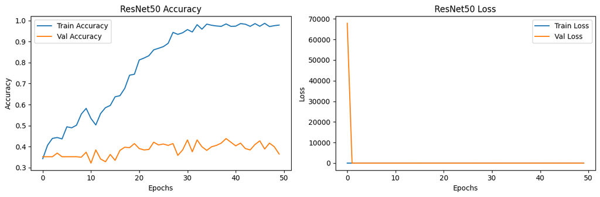

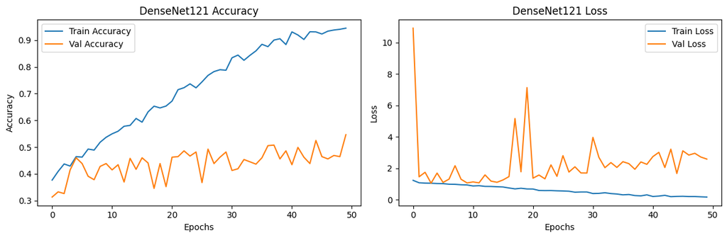

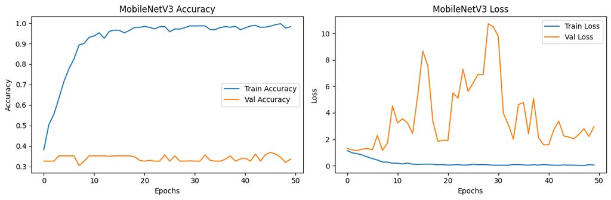

```python
def plot_history(history, model_name):
    plt.figure(figsize=(12, 4))

    # Accuracy
    plt.subplot(1, 2, 1)
    plt.plot(history.history['accuracy'], label='Train Accuracy')
    plt.plot(history.history['val_accuracy'], label='Val Accuracy')
    plt.title(f'{model_name} Accuracy')
    plt.xlabel('Epochs')
    plt.ylabel('Accuracy')
    plt.legend()

    # Loss
    plt.subplot(1, 2, 2)
    plt.plot(history.history['loss'], label='Train Loss')
    plt.plot(history.history['val_loss'], label='Val Loss')
    plt.title(f'{model_name} Loss')
    plt.xlabel('Epochs')
    plt.ylabel('Loss')
    plt.legend()

    plt.tight_layout()
    plt.show()

# Plot for all models
for name, history in histories.items():
    plot_history(history, name)
```

Confusion Matrices

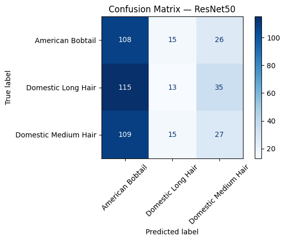

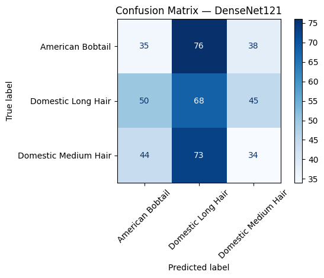

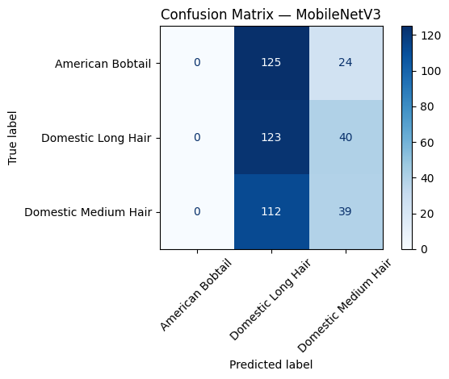

```python
from sklearn.metrics import confusion_matrix, ConfusionMatrixDisplay

def show_confusion_matrix(model, test_data, model_name):
    test_data.reset()
    y_true = test_data.classes
    y_pred = np.argmax(model.predict(test_data, verbose=0), axis=1)

    cm = confusion_matrix(y_true, y_pred)
    disp = ConfusionMatrixDisplay(confusion_matrix=cm, display_labels=class_names)
    disp.plot(cmap='Blues', xticks_rotation=45)
    plt.title(f'Confusion Matrix — {model_name}')
    plt.tight_layout()
    plt.show()

# Run for all models
for name, model in models_dict.items():
    show_confusion_matrix(model, test_data, name)
```

Test Accuracy, Training Time, Parameters, and mAP

```python
from sklearn.metrics import precision_recall_fscore_support
import time

evaluation_results = []

for name, model in models_dict.items():
    print(f"⏱ Evaluating {name}")
    test_data.reset()

    start = time.time()
    loss, acc = model.evaluate(test_data, verbose=0)
    end = time.time()

    y_true = test_data.classes
    y_pred = np.argmax(model.predict(test_data, verbose=0), axis=1)
    precision, _, _, _ = precision_recall_fscore_support(y_true, y_pred, average=None)
    mAP = np.mean(precision)

    evaluation_results.append({
        'Model': name,
        'Test Accuracy (%)': round(acc * 100, 2),
        'mAP': round(mAP, 4),
        'Parameters': model.count_params(),
        'Eval Time (s)': round(end - start, 2)
    })

# Show as DataFrame
import pandas as pd
df_summary = pd.DataFrame(evaluation_results).sort_values(by='Test Accuracy (%)', ascending=False)
print(df_summary)
```

```
⏱ Evaluating ResNet50
⏱ Evaluating DenseNet121
⏱ Evaluating MobileNetV3
         Model  Test Accuracy (%)     mAP  Parameters  Eval Time (s)
1  DenseNet121              45.79  0.3118     7300675           1.41
0     ResNet50              36.93  0.3466    24113027           1.52
2  MobileNetV3              34.77  0.2188     1087603           1.20
```

Conclusion

In this project, we trained and evaluated three state-of-the-art convolutional neural networks — ResNet50, DenseNet121, and MobileNetV3 — using transfer learning to classify 3 cat breeds. Each model was assessed based on:

Test Accuracy – overall prediction correctness

mAP (Mean Average Precision) – per-class precision

Parameter Count – model size/complexity

Evaluation Time – efficiency during inference

In this project, we trained and evaluated three state-of-the-art convolutional neural networks — ResNet50, DenseNet121, and MobileNetV3 — using transfer learning to classify 3 cat breeds. Each model was assessed based on:

Test Accuracy – overall prediction correctness

mAP (Mean Average Precision) – per-class precision

Parameter Count – model size/complexity

Evaluation Time – efficiency during inference

Considering all evaluation criteria:

If prediction accuracy is the top priority, ✅ DenseNet121 is the best model for this task.

If per-class precision (mAP) matters more (e.g., fairness across classes), 🟨 ResNet50 may be preferred.

If you need a fast and lightweight model for deployment on mobile or edge devices, 🟧 MobileNetV3 is a practical compromise, but at the cost of accuracy.

🏁 Therefore, DenseNet121 is the most balanced and best-suited model for this 3-class cat breed classification problem, offering the highest test accuracy with moderate size and inference time.